# Reviewers comment v1

Hello Tyler!

Im happy to review your project today 🙌

My name is **Gerardo Flores** and you can find me on the HUB as https://hub.tripleten.com/u/dea170e1

You can find my comments under the heading **«Review»**. I will categorize my comments in green, blue or red boxes like this:

**Success:** if everything is done successfully

**Remarks:** if I can give some recommendations or ways to improve the project

**Needs fixing:** if the block requires some corrections. Work cant be accepted with the red comments

Please dont remove my comments :) If you have any questions dont hesitate to respond to my comments in a different section.

**Student comments:** For example like this

**Reviewer's comment v1:**

**Overall Feedback**

Hello Tyler,

Another project successfully completed - well done! 🏆 Your consistent effort and progress are truly commendable. There are no critical issues, so your project has been accepted! You can find more detailed notes within your project notebook in the **Reviewer's comment v1:** sections.

Congratulations again on your accomplishment! You truly did an amazing job. Each project you complete adds to your growing expertise, and it’s exciting to see you making such great strides. Keep up the great work! 🎯

PS: As a final suggestion, I recommend trying out some practice tasks with pandas: https://www.machinelearningplus.com/python/101-pandas-exercises-python/ 🙌

**Reviewer's comment v1**

It would be immensely helpful if you can add some contextual information at the beginning of the notebook, covering:

- A brief description of the project's objective.
- An overview of the data you're working with.
- Any expected outcomes or results you aim to achieve.

Providing such context allows anyone reviewing or revisiting the notebook to quickly understand its purpose and the data being used, ensuring smoother collaboration and more intuitive navigation.

# Instacart Market Basket Analysis

## Importing the required libraries

```python
# Import the libraries you'll need for this analysis
import pandas as pd
import matplotlib.pyplot as plt
```

```python
# Load the datasets
# Note: These files use semicolon (;) as the separator instead of comma
orders         = pd.read_csv('/datasets/instacart_orders.csv', sep=';')
products       = pd.read_csv('/datasets/products.csv', sep=';')
departments    = pd.read_csv('/datasets/departments.csv', sep=';')
aisles         = pd.read_csv('/datasets/aisles.csv', sep=';')
order_products = pd.read_csv('/datasets/order_products.csv', sep=';')
```

## Analyze your data

In the cells below, display the datasets using `.info()` and `.head()` to gain insights into their structure and content.

- `.info()`: Provides a concise summary of the dataset, including the data types, non-null counts, and memory usage.
- `.head()`: Displays the first few rows of the dataset, offering a quick overview of the data values.

```python
# In this cell, type "orders" below this line and execute the cell #for the sake of clutter, im not using head(),
#since just typing the df name shows a limited table

orders
```

|  | order_id | user_id | order_number | order_dow | order_hour_of_day | days_since_prior_order |
| --- | --- | --- | --- | --- | --- | --- |
| 0 | 1515936 | 183418 | 11 | 6 | 13 | 30.0 |
| 1 | 1690866 | 163593 | 5 | 5 | 12 | 9.0 |
| 2 | 1454967 | 39980 | 4 | 5 | 19 | 2.0 |
| 3 | 1768857 | 82516 | 56 | 0 | 20 | 10.0 |
| 4 | 3007858 | 196724 | 2 | 4 | 12 | 17.0 |
| ... | ... | ... | ... | ... | ... | ... |
| 478962 | 3210681 | 5617 | 5 | 1 | 14 | 7.0 |
| 478963 | 3270802 | 112087 | 2 | 3 | 13 | 6.0 |
| 478964 | 885349 | 82944 | 16 | 2 | 11 | 6.0 |
| 478965 | 216274 | 4391 | 3 | 3 | 8 | 8.0 |
| 478966 | 2071924 | 1730 | 18 | 1 | 14 | 15.0 |

478967 rows × 6 columns

```python
# In this cell, type "orders.info() below this line and execute the cell
orders.info()
```

```
<class 'pandas.core.frame.DataFrame'>
RangeIndex: 478967 entries, 0 to 478966
Data columns (total 6 columns):
 #   Column                  Non-Null Count   Dtype
---  ------                  --------------   -----
 0   order_id                478967 non-null  int64
 1   user_id                 478967 non-null  int64
 2   order_number            478967 non-null  int64
 3   order_dow               478967 non-null  int64
 4   order_hour_of_day       478967 non-null  int64
 5   days_since_prior_order  450148 non-null  float64
dtypes: float64(1), int64(5)
memory usage: 21.9 MB
```

```python
# days_since_prior_order has less non-null values
```

```python
# In this cell, type "products" below this line and execute the cell
products
```

|  | product_id | product_name | aisle_id | department_id |
| --- | --- | --- | --- | --- |
| 0 | 1 | Chocolate Sandwich Cookies | 61 | 19 |
| 1 | 2 | All-Seasons Salt | 104 | 13 |
| 2 | 3 | Robust Golden Unsweetened Oolong Tea | 94 | 7 |
| 3 | 4 | Smart Ones Classic Favorites Mini Rigatoni Wit... | 38 | 1 |
| 4 | 5 | Green Chile Anytime Sauce | 5 | 13 |
| ... | ... | ... | ... | ... |
| 49689 | 49690 | HIGH PERFORMANCE ENERGY DRINK | 64 | 7 |
| 49690 | 49691 | ORIGINAL PANCAKE & WAFFLE MIX | 130 | 14 |
| 49691 | 49692 | ORGANIC INSTANT OATMEAL LIGHT MAPLE BROWN SUGAR | 130 | 14 |
| 49692 | 49693 | SPRING WATER BODY WASH | 127 | 11 |
| 49693 | 49694 | BURRITO- STEAK & CHEESE | 38 | 1 |

49694 rows × 4 columns

```python
products.info()
```

```
<class 'pandas.core.frame.DataFrame'>
RangeIndex: 49694 entries, 0 to 49693
Data columns (total 4 columns):
 #   Column         Non-Null Count  Dtype
---  ------         --------------  -----
 0   product_id     49694 non-null  int64
 1   product_name   48436 non-null  object
 2   aisle_id       49694 non-null  int64
 3   department_id  49694 non-null  int64
dtypes: int64(3), object(1)
memory usage: 1.5+ MB
```

```python
#product_name has less non-null values
```

```python
departments #showing departments df
```

|  | department_id | department |
| --- | --- | --- |
| 0 | 1 | frozen |
| 1 | 2 | other |
| 2 | 3 | bakery |
| 3 | 4 | produce |
| 4 | 5 | alcohol |
| 5 | 6 | international |
| 6 | 7 | beverages |
| 7 | 8 | pets |
| 8 | 9 | dry goods pasta |
| 9 | 10 | bulk |
| 10 | 11 | personal care |
| 11 | 12 | meat seafood |
| 12 | 13 | pantry |
| 13 | 14 | breakfast |
| 14 | 15 | canned goods |
| 15 | 16 | dairy eggs |
| 16 | 17 | household |
| 17 | 18 | babies |
| 18 | 19 | snacks |
| 19 | 20 | deli |
| 20 | 21 | missing |

```python
departments.info()
```

```
<class 'pandas.core.frame.DataFrame'>
RangeIndex: 21 entries, 0 to 20
Data columns (total 2 columns):
 #   Column         Non-Null Count  Dtype
---  ------         --------------  -----
 0   department_id  21 non-null     int64
 1   department     21 non-null     object
dtypes: int64(1), object(1)
memory usage: 464.0+ bytes
```

```python
aisles #showing aisles df
```

|  | aisle_id | aisle |
| --- | --- | --- |
| 0 | 1 | prepared soups salads |
| 1 | 2 | specialty cheeses |
| 2 | 3 | energy granola bars |
| 3 | 4 | instant foods |
| 4 | 5 | marinades meat preparation |
| ... | ... | ... |
| 129 | 130 | hot cereal pancake mixes |
| 130 | 131 | dry pasta |
| 131 | 132 | beauty |
| 132 | 133 | muscles joints pain relief |
| 133 | 134 | specialty wines champagnes |

134 rows × 2 columns

```python
aisles.info()
```

```
<class 'pandas.core.frame.DataFrame'>
RangeIndex: 134 entries, 0 to 133
Data columns (total 2 columns):
 #   Column    Non-Null Count  Dtype
---  ------    --------------  -----
 0   aisle_id  134 non-null    int64
 1   aisle     134 non-null    object
dtypes: int64(1), object(1)
memory usage: 2.2+ KB
```

```python
order_products #showing order_products df
```

|  | order_id | product_id | add_to_cart_order | reordered |
| --- | --- | --- | --- | --- |
| 0 | 2141543 | 11440 | 17.0 | 0 |
| 1 | 567889 | 1560 | 1.0 | 1 |
| 2 | 2261212 | 26683 | 1.0 | 1 |
| 3 | 491251 | 8670 | 35.0 | 1 |
| 4 | 2571142 | 1940 | 5.0 | 1 |
| ... | ... | ... | ... | ... |
| 4545002 | 577211 | 15290 | 12.0 | 1 |
| 4545003 | 1219554 | 21914 | 9.0 | 0 |
| 4545004 | 692640 | 47766 | 4.0 | 1 |
| 4545005 | 319435 | 691 | 8.0 | 1 |
| 4545006 | 1398151 | 28733 | 9.0 | 0 |

4545007 rows × 4 columns

**Reviewer's comment v1**

Please don't forget to use `head`, `tail` or `sample` when showing dataframes. If you leave this table "as is", then when you save the notebook, for example, on github, the table will expand to its full length and take up a significant part of the report.

```python
order_products.info()
```

```
<class 'pandas.core.frame.DataFrame'>
RangeIndex: 4545007 entries, 0 to 4545006
Data columns (total 4 columns):
 #   Column             Dtype
---  ------             -----
 0   order_id           int64
 1   product_id         int64
 2   add_to_cart_order  float64
 3   reordered          int64
dtypes: float64(1), int64(3)
memory usage: 138.7 MB
```

Repeat this process for each dataset to understand the structure, including the types of columns and rows they contain. Add additional code cells as needed for your analysis.

```python
# In this cell, run orders_products.info() below, but include the argument show_counts=True since this is a large file.
order_products.info(show_counts= True)
```

```
<class 'pandas.core.frame.DataFrame'>
RangeIndex: 4545007 entries, 0 to 4545006
Data columns (total 4 columns):
 #   Column             Non-Null Count    Dtype
---  ------             --------------    -----
 0   order_id           4545007 non-null  int64
 1   product_id         4545007 non-null  int64
 2   add_to_cart_order  4544171 non-null  float64
 3   reordered          4545007 non-null  int64
dtypes: float64(1), int64(3)
memory usage: 138.7 MB
```

```python
#add_to_cart_order has less non-null values
```

Repeat the use of .info() on the remaining datasets to identify missing values and understand their structure. Check the "Non-Null Count" for each dataset to spot any columns with missing values.

## Find and Remove Missing Values

We noticed that some columns contain missing values.

Here are some useful code snippets:

```
# Identify missing values in each column
print(dataset.isnull().sum())

# Display rows where a specific column has missing values
print(dataset[dataset['column_name'].isna()])

# Confirm no missing values remain
print(dataset.isnull().sum())
```

### `products` Data Frame

We will begin by addressing the missing values in the `products` data frame.

```python
# Display rows where the product_name column has missing values
print(products[products['product_name'].isna()])
```

```
       product_id product_name  aisle_id  department_id
37             38          NaN       100             21
71             72          NaN       100             21
109           110          NaN       100             21
296           297          NaN       100             21
416           417          NaN       100             21
...           ...          ...       ...            ...
49552       49553          NaN       100             21
49574       49575          NaN       100             21
49640       49641          NaN       100             21
49663       49664          NaN       100             21
49668       49669          NaN       100             21

[1258 rows x 4 columns]
```

It seems suspicious that all rows with missing `product_name` might be associated with `aisle_id` 100 and `department_id` 21. Let’s verify this by checking if any rows with missing `product_name` have an `aisle_id` different from 100 and 21. This will help us confirm if the issue is isolated to this aisle or spread across others.

```python
# Combine conditions to check for missing product names in aisles other than 100
print(products[(products['product_name'].isna()) & (products['aisle_id'] != 100)])
```

```
Empty DataFrame
Columns: [product_id, product_name, aisle_id, department_id]
Index: []
```

```python
#no missing product names outside row 100
```

```python
# Combine conditions to check for missing product names in aisles other than 21
print(products[(products['product_name'].isna()) & (products['department_id'] != 21)])
```

```
Empty DataFrame
Columns: [product_id, product_name, aisle_id, department_id]
Index: []
```

```python
#no missing product names outside department 21
```

To better understand the missing product_name values, let’s determine what department_id 21 and aisle_id 100 represent by referencing the departments and aisles tables.

```python
#using == to identify specific row, could also use .loc or .iloc but i find this easier to see
```

```python
# What is this aisle and department?
print(aisles[aisles['aisle_id'] == 100])
print(departments[departments['department_id'] == 21])
```

```
    aisle_id    aisle
99       100  missing
    department_id department
20             21    missing
```

```python
# Fill missing product names with 'Unknown'
print(aisles.loc[99]) #verify row i need to change
```

```
aisle_id        100
aisle       missing
Name: 99, dtype: object
```

```python
aisles.loc[99, 'aisle'] = 'Unknown'

#replaced missing with unknow using loc
```

```python
print(aisles.loc[97:100]) #verify other aisle names werent changed
```

```
     aisle_id                    aisle
97         98            juice nectars
98         99  canned fruit applesauce
99        100                  Unknown
100       101   air fresheners candles
```

```python
print(departments.loc[20])
```

```
department_id         21
department       missing
Name: 20, dtype: object
```

```python
departments.loc[20, 'department'] = 'Unknown' #change specific row and column
```

```python
print(departments.loc[18:23])
#verify no other rows were changed
```

```
    department_id department
18             19     snacks
19             20       deli
20             21    Unknown
```

```python
#only changes aisles and department df, need to change products df
products = products.fillna('Unknown')
```

### `orders` data frame

Now let's fill in missing values from the `orders` table.

```python
# Display rows where the days_since_prior_order column has missing values
print(orders[orders['days_since_prior_order'].isna()])
```

```
        order_id  user_id  order_number  order_dow  order_hour_of_day  \
28        133707   182261             1          3                 10
96        787445    25685             1          6                 18
100       294410   111449             1          0                 19
103      2869915   123958             1          4                 16
104      2521921    42286             1          3                 18
...          ...      ...           ...        ...                ...
478895   2589657   205028             1          0                 16
478896   2222353   141211             1          2                 13
478922   2272807   204154             1          1                 15
478926   2499542    68810             1          4                 19
478945   1387033    22496             1          5                 14

        days_since_prior_order
28                         NaN
96                         NaN
100                        NaN
103                        NaN
104                        NaN
...                        ...
478895                     NaN
478896                     NaN
478922                     NaN
478926                     NaN
478945                     NaN

[28819 rows x 6 columns]
```

```python
# Are there any missing values where it's not a customer's first order?
print(orders[(orders['days_since_prior_order'].isna()) & (orders['order_number'] != 1)]) #check for nan data for order other than 1 order
```

```
Empty DataFrame
Columns: [order_id, user_id, order_number, order_dow, order_hour_of_day, days_since_prior_order]
Index: []
```

```python
#no NaN values outside of customers first order, no issues!
```

All of the missing `'days_since_prior_order'` values correspond to a customer's first ever order. This makes sense because there is no prior order! We'll leave the values as `NaN` so the column can remain numeric. Also, the `NaN` values shouldn't interfere with any calculations we might do using this column.

### `order_products` data frame

Now let's fill in missing values from the order_products table.

```python
# Display rows where the add_to_cart_order column has missing values
print(order_products[order_products['add_to_cart_order'].isna()])
```

```
         order_id  product_id  add_to_cart_order  reordered
737       2449164        5068                NaN          0
9926      1968313       43867                NaN          0
14394     2926893       11688                NaN          0
16418     1717990        4142                NaN          0
30114     1959075       42828                NaN          1
...           ...         ...                ...        ...
4505662   1800005        7411                NaN          0
4511400   1633337         260                NaN          0
4517562    404157        9517                NaN          0
4534112   1673227       17835                NaN          0
4535739   1832957       17949                NaN          1

[836 rows x 4 columns]
```

```python
# Use .min() and .max() to find the minimum and maximum values for this column.
print(order_products['add_to_cart_order'].min(), order_products['add_to_cart_order'].max())
```

```
1.0 64.0
```

```python
# Save all order IDs with at least one missing value in 'add_to_cart_order'
missing_add_to_cart_orders = order_products[order_products['add_to_cart_order'].isna()] #make seperate variable for missing
missing_unique= missing_add_to_cart_orders['order_id'].unique()  #make variable for unique order ids for missing
print(missing_unique)
```

```
[2449164 1968313 2926893 1717990 1959075  844733   61355  936852  264710
 1564093  129627  293169 2849370 1386261 3308010  903110 2136777 3347453
 1888628  165801 2094761 1038146 2997021  813364 2256933  171934 2409109
 1730767 1169835  733526  404157 3125735  747668 1800005 1961723  871281
  388234 1648217 1477139  102236 1021563 1832957 2721963  678116 1220886
 1673227 2999801 1633337 2470674 2625444 1677118 2479011 3383594 1183255
 1713430 2652650 1598369 1916118  854647 1302315  888470  180546 2621907
 1308785 2729254    9310 2170451 2979697 1625713 1529171]
```

```python
# Do all orders with missing values have more than 64 products?
order_products['add_to_cart_order'].value_counts().sort_index()
#shows that the values end at 64 #kind of unneccessary since we did the min() max()
```

```
1.0     450046
2.0     428199
3.0     401907
4.0     372861
5.0     341807
         ...
60.0       127
61.0       114
62.0        98
63.0        87
64.0        75
Name: add_to_cart_order, Length: 64, dtype: int64
```

```python
order_products['add_to_cart_order'].value_counts().sum() #shows that all numbers from 1-64 make up the Non-null count
```

```
4544171
```

```python
# Replace missing values with 999 and convert column to integer type
order_products['add_to_cart_order'] = order_products['add_to_cart_order'].fillna(999)#fill nan with 999
order_products['add_to_cart_order'] = order_products['add_to_cart_order'].astype('int')# change to int
print(order_products)
print()
print(order_products['add_to_cart_order'].min(), order_products['add_to_cart_order'].max())#show max has changed
print()
print(order_products[order_products['add_to_cart_order'].isna()]) #show nan is empty
print()
order_products.info() #show change to int
```

```
         order_id  product_id  add_to_cart_order  reordered
0         2141543       11440                 17          0
1          567889        1560                  1          1
2         2261212       26683                  1          1
3          491251        8670                 35          1
4         2571142        1940                  5          1
...           ...         ...                ...        ...
4545002    577211       15290                 12          1
4545003   1219554       21914                  9          0
4545004    692640       47766                  4          1
4545005    319435         691                  8          1
4545006   1398151       28733                  9          0

[4545007 rows x 4 columns]

1 999

Empty DataFrame
Columns: [order_id, product_id, add_to_cart_order, reordered]
Index: []

<class 'pandas.core.frame.DataFrame'>
RangeIndex: 4545007 entries, 0 to 4545006
Data columns (total 4 columns):
 #   Column             Dtype
---  ------             -----
 0   order_id           int64
 1   product_id         int64
 2   add_to_cart_order  int64
 3   reordered          int64
dtypes: int64(4)
memory usage: 138.7 MB
```

```python
#now we have the same amount of non null values and we show that our max value is 999 in add_to_cart_order.
#we also show we changed type to int
```

For some reason, any item placed in the cart 65th or later has a missing value in the `'add_to_cart_order'` column. Maybe the data type of that column in the database could only hold integer values from 1 to 64. We've decided to replace the missing values with a code value, 999, that represents an unknown placed in cart order above 64. We also converted the column to integer data type. We just need to be careful to remember this if we perform calculations using this column during our analysis.

Other sensible code values we could've used are 0 or -1 because they don't show up elsewhere in the dataset and they don't have any real physical meaning for this variable.

Also note that, for orders with exactly 65 items, we could replace the missing value with 65. But we're going to neglect that for now since we can't determine the 65th item for all orders with 66 items or more.

**Reviewer's comment v1**

Overall, your exploration and cleaning process is well-thought-out.

You correctly identified and addressed NaN values in `product_name`, `days_since_prior_order`, `add_to_cart_order`.

## Find and Remove Duplicate Values from All the Datasets

Each dataset may contain duplicate rows, which can lead to redundancy and affect the accuracy of our analysis. To handle this:

1. Use the `.duplicated()` method to identify duplicate rows. This method returns a Boolean series where `True` indicates a duplicate row.
2. Apply the `.drop_duplicates()` method to remove these duplicate rows, ensuring a cleaner dataset.
3. Optionally, you can set the `keep` parameter in `.drop_duplicates()` to specify which duplicate to retain (`'first'` or `'last'`).

Here is some example code for reference:

```
# Check for duplicates
print(dataset.duplicated().sum())  # Number of duplicate rows

# View duplicate rows
print(dataset[dataset.duplicated()]

# Remove duplicates
dataset = dataset.drop_duplicates().reset_index(drop=True)

# Confirm removal
print(dataset.duplicated().sum())  # Should return 0
```

Repeat this process for all datasets to ensure they are free of duplicate rows.

### `orders` data frame

```python
# Find the number of duplicate rows in the orders dataframe
print(orders['order_id'].duplicated().sum())
#only need to check for order_id because all other variables can regularly show up multiple times
```

```
15
```

```python
# View the duplicate rows
print(orders[orders['order_id'].duplicated()])
#shows instances where order id is duplicated, does not show original instance
```

```
        order_id  user_id  order_number  order_dow  order_hour_of_day  \
145574    794638    50898            24          3                  2
223105   2160484   107525            16          3                  2
230807   1918001   188546            14          3                  2
266232   1782114   106752             1          3                  2
273805   1112182   202304            84          3                  2
284038   2845099    31189            11          3                  2
311713   1021560    53767             3          3                  2
321100    408114    68324             4          3                  2
323900   1919531   191501            32          3                  2
345917   2232988    82565             1          3                  2
371905    391768    57671            19          3                  2
394347    467134    63189            21          3                  2
411408   1286742   183220            48          3                  2
415163   2282673    86751            49          3                  2
```

[output cut: 18 more lines]

```python
#i wanted to see the actuall duplicates because i dont trust the system to be correct
dup_order_id = orders[orders['order_id'].duplicated()] #assinged the duplicates to a variable
unique_duplicates = dup_order_id['order_id'].unique() #made another variable to get the unique values
print(unique_duplicates)
print()
print(orders[orders['order_id'].isin(unique_duplicates)])
#printed all instances where unique_duplicates occured in the order_id column, this way i could see if the id actually repeated
```

```
[ 794638 2160484 1918001 1782114 1112182 2845099 1021560  408114 1919531
 2232988  391768  467134 1286742 2282673 2125197]

        order_id  user_id  order_number  order_dow  order_hour_of_day  \
30371    1918001   188546            14          3                  2
99462     794638    50898            24          3                  2
119251    408114    68324             4          3                  2
142258   2845099    31189            11          3                  2
145574    794638    50898            24          3                  2
164581   1112182   202304            84          3                  2
200059   1782114   106752             1          3                  2
204042   2125197    14050            48          3                  2
215294   2160484   107525            16          3                  2
223105   2160484   107525            16          3                  2
230807   1918001   188546            14          3                  2
```

[output cut: 51 more lines]

```python
# Remove duplicate orders
orders = orders.drop_duplicates().reset_index(drop=True)
#, i could have used more complicated methods(DOT suggested), but this way is so simple. and provided
```

```python
# Double check for duplicate rows
print(orders)
```

```
        order_id  user_id  order_number  order_dow  order_hour_of_day  \
0        1515936   183418            11          6                 13
1        1690866   163593             5          5                 12
2        1454967    39980             4          5                 19
3        1768857    82516            56          0                 20
4        3007858   196724             2          4                 12
...          ...      ...           ...        ...                ...
478947   3210681     5617             5          1                 14
478948   3270802   112087             2          3                 13
478949    885349    82944            16          2                 11
478950    216274     4391             3          3                  8
478951   2071924     1730            18          1                 14

        days_since_prior_order
0                         30.0
1                          9.0
2                          2.0
3                         10.0
4                         17.0
...                        ...
478947                     7.0
478948                     6.0
478949                     6.0
478950                     8.0
478951                    15.0

[478952 rows x 6 columns]
```

### `products` data frame

```python
# Check for just duplicate product IDs using subset='product_id' in duplicated()
print(products[products.duplicated(subset = 'product_id')])
```

```
Empty DataFrame
Columns: [product_id, product_name, aisle_id, department_id]
Index: []
```

Hint: To identify duplicate product names more effectively, convert the names to lowercase for consistent comparison. Use the .str.lower() method on the product_name column to standardize the text before checking for duplicates.

```python
# Check for just duplicate product names (convert names to lowercase to compare better)
products['product_name'] = products['product_name'].str.lower()
print(products[products['product_name'].duplicated()])
```

```
       product_id                                     product_name  aisle_id  \
71             72                                          unknown       100
109           110                                          unknown       100
296           297                                          unknown       100
416           417                                          unknown       100
436           437                                          unknown       100
...           ...                                              ...       ...
49689       49690                    high performance energy drink        64
49690       49691                    original pancake & waffle mix       130
49691       49692  organic instant oatmeal light maple brown sugar       130
49692       49693                           spring water body wash       127
49693       49694                          burrito- steak & cheese        38

       department_id
71                21
109               21
296               21
416               21
436               21
...              ...
49689              7
49690             14
49691             14
49692             11
49693              1

[1361 rows x 4 columns]
```

Let's see what that looks like in our dataset :

```python
products[products['product_name'].str.lower() == 'high performance energy drink']
```

|  | product_id | product_name | aisle_id | department_id |
| --- | --- | --- | --- | --- |
| 22540 | 22541 | high performance energy drink | 64 | 7 |
| 49689 | 49690 | high performance energy drink | 64 | 7 |

```python
# Drop duplicate product names (case insensitive)
#i want to keep unknown product names because they are still useful for my data, however this makes it a tad more difficult
#to drop duplicates
unknown_products = products[products['product_name'] == 'unknown'] #set variable for unknown products
products = products.drop_duplicates(subset= 'product_name') #drop all duplicates in product name
products = pd.concat([products, unknown_products]).reset_index(drop=True)
#use the concat method we learned to merge my unknown products dataframe with my original corrected df
```

```python
# Check for fully duplicate rows
print(products[products.duplicated()])
#because i added all unknowns back and removing duplicates kept 1, i need to remove the extra
```

```
       product_id product_name  aisle_id  department_id
48333          38      unknown       100             21
```

```python
products = products.drop(index= 48333).reset_index(drop= True)
#removing all duplicates woulld get rid of my unknowns, so i need to pick it straight from the index
print(products[products.duplicated()]) #no more dups
```

```
Empty DataFrame
Columns: [product_id, product_name, aisle_id, department_id]
Index: []
```

```python
print(products[products['product_name'] == 'unknown'])

#my unknowns still exist! perfect, now i got rid of all of the real duplicates without getting rid of useful data.
```

```
       product_id product_name  aisle_id  department_id
37             38      unknown       100             21
48333          72      unknown       100             21
48334         110      unknown       100             21
48335         297      unknown       100             21
48336         417      unknown       100             21
...           ...          ...       ...            ...
49585       49553      unknown       100             21
49586       49575      unknown       100             21
49587       49641      unknown       100             21
49588       49664      unknown       100             21
49589       49669      unknown       100             21

[1258 rows x 4 columns]
```

### `departments` data frame

```python
# Check for duplicate entries in the departments dataframe
print(departments[departments.duplicated()])
#no duplicates so proceed form now
```

```
Empty DataFrame
Columns: [department_id, department]
Index: []
```

### `aisles` data frame

```python
# Check for duplicate entries in the aisles dataframe
print(aisles[aisles.duplicated()])
#looks clear here too!
```

```
Empty DataFrame
Columns: [aisle_id, aisle]
Index: []
```

### `order_products` data frame

```python
# Check for duplicate entries in the order_products dataframe
print(order_products[order_products.duplicated()])
#oh thank goodness, no duplicates!
```

```
Empty DataFrame
Columns: [order_id, product_id, add_to_cart_order, reordered]
Index: []
```

We have now successfully cleaned our data. Let's begin our exploratory data analysis.

**Reviewer's comment v1**

You've done a good job at checking duplicates in the tables.

# [A] Easy (must complete all to pass)

### [A1] Verify that the `'order_hour_of_day'` and `'order_dow'` values in the `orders` tables are sensible (i.e. `'order_hour_of_day'` ranges from 0 to 23 and `'order_dow'` ranges from 0 to 6)

To verify that the values in the `order_hour_of_day` and `order_dow` columns are sensible:

1. **Check unique values**: Use `.unique()` on each column to extract all distinct values present.
2. **Sort the results**: Use `sorted()` to arrange the unique values in ascending order for easier verification.
3. **Validate ranges**:
   - Ensure `order_hour_of_day` values range from 0 to 23 (representing hours of the day).
   - Ensure `order_dow` values range from 0 to 6 (representing days of the week).

This process confirms that the data aligns with expected ranges and there are no out-of-bound or invalid entries.

```python
unique_orders_hod = orders['order_hour_of_day'].unique()#make unique variables
unique_orders_dow = orders['order_dow'].unique()
print(sorted(unique_orders_hod))
print(sorted(unique_orders_dow)) #good!
```

```
[0, 1, 2, 3, 4, 5, 6, 7, 8, 9, 10, 11, 12, 13, 14, 15, 16, 17, 18, 19, 20, 21, 22, 23]
[0, 1, 2, 3, 4, 5, 6]
```

```python
#looks like the ranges match up with what we need!
```

**Reviewer's comment v1**

You correctly verified that `order_hour_of_day` ranges from 0 to 23 and `order_dow` ranges from 0 to 6 using `.unique()` and `sorted()`.

As a second approach you could use `.describe()` function for getting an initial understanding of data, especially for numeric columns. However, this function might return descriptive statistics for all numeric columns in the dataframe. If you are interested in specific columns, you might want to narrow it down.

`orders[['order_hour_of_day', 'order_dow']].describe()`

### [A2] What time of day do people shop for groceries?

To determine the time of day people shop for groceries, analyze the order_hour_of_day column in the orders dataset. Use .value_counts() to count the number of orders placed at each hour, and then sort the results by the hour for a clear chronological order.

Finally, visualize the data with a bar plot to easily observe the shopping trends across different times of the day.

```python
value_counts_hod = orders['order_hour_of_day'].value_counts().sort_index() #create variable for sorted df
order_counts_table_hod = pd. DataFrame({'hour': value_counts_hod.index, 'orders': value_counts_hod.values}) #create a new df to use for illustration
print(order_counts_table_hod) #print to make sure its the information we need
```

```
    hour  orders
0      0    3180
1      1    1763
2      2     989
3      3     770
4      4     765
5      5    1371
6      6    4215
7      7   13043
8      8   25024
9      9   35896
10    10   40578
11    11   40032
12    12   38034
13    13   39007
14    14   39631
15    15   39789
16    16   38112
17    17   31930
18    18   25510
19    19   19547
20    20   14624
21    21   11019
22    22    8512
23    23    5611
```

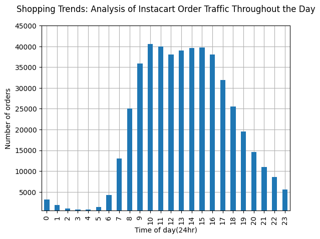

```python
order_counts_table_hod.plot(kind= 'bar', x= 'hour', y= 'orders', xlabel= "Time of day(24hr)", ylabel= "Number of orders", ylim= [500,45000], legend= None, grid=True, zorder= 3)

plt.title('Shopping Trends: Analysis of Instacart Order Traffic Throughout the Day', pad=20)
plt.show()
#I stuck to the 24hr time due to keeping all information as close to the original as possible, and i think adding the grid lines helps visualize the scope of the numbers a bit better than without
```

Most orders occur between 9:00 AM and 5:00 PM, with peaks at 10:00 AM and 3:00 PM

**Reviewer's comment v1**

The bar plot clearly shows orders per hour. Agree with the results and conclusions.

### [A3] What day of the week do people shop for groceries?

To figure out what day of the week people shop for groceries, analyze the order_dow column in the orders dataset. Use .value_counts() to count the number of orders for each day of the week, and then sort the results by the day index to maintain the correct order.

Visualize the data with a bar plot to clearly observe shopping patterns across the days of the week.

```python
value_counts_dow = orders['order_dow'].value_counts().sort_index() #create variable for sorted df
order_counts_table_dow = pd. DataFrame({'day': value_counts_dow.index, 'orders': value_counts_dow.values})
#create new df to use for illustration
order_counts_table_dow['day'] = order_counts_table_dow['day'].replace({0: 'Sunday', 1: 'Monday',  2: 'Tuesday', 3: 'Wednesday', 4: 'Thursday', 5: 'Friday', 6: 'Saturday'})
#replace with days so that illustartion is easily understood
print(order_counts_table_dow) #check to see if info is what we need
#assuming 0 is Sunday
```

```
         day  orders
0     Sunday   84090
1     Monday   82185
2    Tuesday   65833
3  Wednesday   60897
4   Thursday   59810
5     Friday   63488
6   Saturday   62649
```

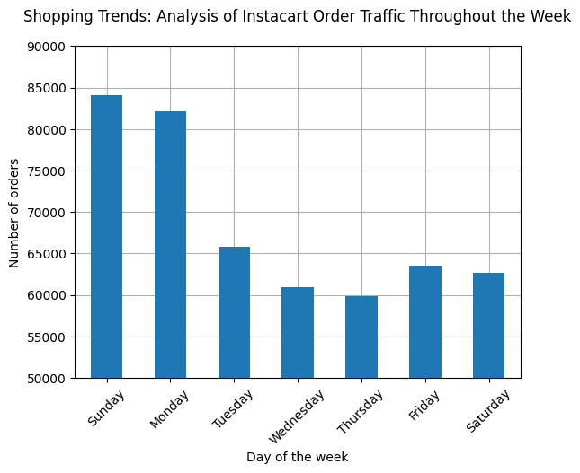

```python
order_counts_table_dow.plot(kind= 'bar', x= 'day', y= 'orders', xlabel= "Day of the week", ylabel= "Number of orders", ylim= [50000,90000], legend= None, grid=True, zorder= 3)
plt.title('Shopping Trends: Analysis of Instacart Order Traffic Throughout the Week', pad=20) #this is my preffered layout for graphs at this current point
plt.xticks(rotation=45) #and for easier readin
plt.show()
```

The data dictionary does not state which integer corresponds to which day of the week. Assuming Sunday = 0, then people place more orders at the beginning of the week (Sunday and Monday).

**Reviewer's comment v1**

You got correct results.

### [A4] How long do people wait until placing another order?

To understand how long people wait before placing another order, analyze the days_since_prior_order column in the orders dataset. Use .value_counts() to count how many orders were placed for each interval of days, then sort the results by the number of days for clarity.

Visualize the data using a bar plot to observe patterns in ordering frequency over time.

```python
value_counts_dspo = orders['days_since_prior_order'].value_counts().sort_index() #create variable for sorted df
order_counts_table_dspo = pd. DataFrame({'days': value_counts_dspo.index, 'people': value_counts_dspo.values}) #ne df to use for illustartions
print(order_counts_table_dspo) #printed to see if this was info i needed
```

```
    days  people
0    0.0    9589
1    1.0   20179
2    2.0   27138
3    3.0   30224
4    4.0   31006
5    5.0   30096
6    6.0   33930
7    7.0   44577
8    8.0   25361
9    9.0   16753
10  10.0   13309
11  11.0   11467
12  12.0   10658
13  13.0   11737
```

[output cut: 17 more lines]

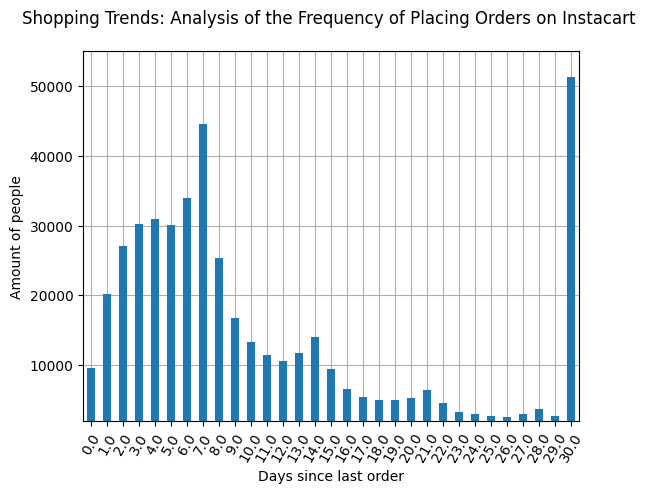

```python
order_counts_table_dspo.plot(kind= 'bar', x= 'days', y= 'people', xlabel= "Days since last order", ylabel= "Amount of people", ylim= [2000,55000], legend= None, grid=True, zorder= 3)
plt.title('Shopping Trends: Analysis of the Frequency of Placing Orders on Instacart ', pad=20) #fab
plt.xticks(rotation=60) #im not sure the rotation works here, tried to widen for more space but i suppose there are limitations
plt.figure(figsize=(20,5))
plt.show()
```

```python
#very weird that the people ordering at 30 is pretty suspicious. its possible that they may have condensed the list at some point
#ex. all people at 30 are a combined amount of people PAST or at 30 days. Also kind of crazy that that many people order multiple times in a day
```

The 0 values probably correspond to customers who placed more than one order on the same day.

The max value of 30 days and the high spike at that value is puzzling though. The spike might be explained by people who set up recurring subscriptions to automatically order once a month. But that doesn't explain why there are no values above 30 days. I would expect many customers to place orders less often than once a month. Maybe those customers were intentionally excluded from the dataset.

Disregarding the spike at 30 days, most people wait between 2 to 10 days in between orders. The most common wait time is 7 days. In other words, it's common for people to place weekly grocery orders. Interestingly, in the tail of the distribution we also see small spikes at 14, 21, and 28 days. These would correspond to orders every 2, 3, or 4 weeks.

**Reviewer's comment v1**

You got correct results.

# [B] Medium (must complete all to pass)

### [B1] Is there a difference in `'order_hour_of_day'` distributions on Wednesdays and Saturdays? Plot the bar charts for both days and describe the differences that you see.

To determine if there's a difference in the `order_hour_of_day` distributions on Wednesdays and Saturdays, follow these steps:

1. **Create masks** for Wednesday (`order_dow == 3`) and Saturday (`order_dow == 6`) to filter the orders data.
2. **Count the order hours** for each day using `.value_counts()` and sort them by hour with `.sort_index()` for clarity.
3. **Combine the counts** for both days into a single DataFrame using `pd.concat()`, and label the columns for easier interpretation.

After preparing the data, plot bar charts for both days to visually compare the distribution of order times. Look for patterns such as peaks or differences in the busiest times throughout the day.

```python
#this ones a doozy
#setting both days to there respecting numbers
wednesday_orders = orders[orders['order_dow'] == 3]
saturday_orders = orders[orders['order_dow'] == 6]
wednesday_sorted_orders = wednesday_orders['order_hour_of_day'].value_counts().sort_index()
#assigning variables
saturday_sorted_orders = saturday_orders['order_hour_of_day'].value_counts().sort_index()
wednesday_orders_table = pd.DataFrame({'hours': wednesday_sorted_orders.index, 'orders': wednesday_sorted_orders.values})
saturday_orders_table = pd.DataFrame({'hours': saturday_sorted_orders.index, 'orders': saturday_sorted_orders.values})
#creating new dataframes for both so that i can combine and use in a new df for illustration
wednesday_saturday_orders_table = pd.concat([wednesday_orders_table, saturday_orders_table], axis=1, keys= ['wednesday', 'saturday'])
#concating like assignemnt requested, added keys in hoped of naming the columns
wednesday_saturday_orders_table = wednesday_saturday_orders_table.drop(('saturday', 'hours'), axis= 1)
#the previous line of code added and extra hours column so this one removes that
wednesday_saturday_orders_table.columns = ['hours', 'wednesday', 'saturday']
#this one just renames my columns so that i can pull the info for the illustration
print(wednesday_saturday_orders_table) #check to seee if layout is correct
```

```
    hours  wednesday  saturday
0       0        373       464
1       1        215       254
2       2        106       177
3       3        101       125
4       4        108       118
5       5        170       161
6       6        643       451
7       7       1732      1619
8       8       3125      3246
9       9       4490      4311
10     10       5026      4919
11     11       5004      5116
12     12       4688      5132
13     13       4674      5323
14     14       4774      5375
15     15       5163      5188
16     16       4976      5029
17     17       4175      4295
18     18       3463      3338
19     19       2652      2610
20     20       1917      1847
21     21       1450      1473
22     22       1154      1185
23     23        718       893
```

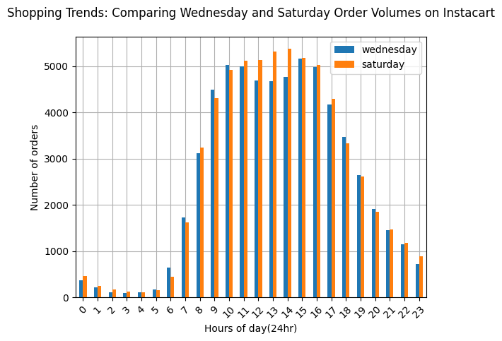

```python
wednesday_saturday_orders_table.plot(kind= 'bar', x= 'hours', xlabel= 'Hours of day(24hr)', ylabel= 'Number of orders', grid= True, zorder= 3)
plt.title('Shopping Trends: Comparing Wednesday and Saturday Order Volumes on Instacart',  pad= 20) #works like a charm
plt.xticks(rotation=45) #those numbers still just look so bad, not sure what else i can do to spread them out without removing data
plt.show()
```

There's a small dip from 11h to 13h on Wednesdays. This dip is absent on Saturdays. Maybe this dip can be attributed to people who don't use Instacart because they have lunch somewhere between 11h and 13h.

**Reviewer's comment v1**

Everything is correct here.

### [B2] What's the distribution for the number of orders per customer?

To explore the distribution of the number of orders per customer:

1. **Group the data** by `user_id` to calculate the total number of orders for each customer. Use `.groupby('user_id')` and count the `order_id` for each group.
2. **Sort the results** using `.sort_values()` for better readability.
3. **Visualize the distribution** using a histogram to observe how many orders most customers typically place.

Adjust the number of bins in the histogram to refine the visualization and better capture the pattern.

```python
user_id_orders = orders.groupby('user_id')['order_id'].count()
user_sort_orders = user_id_orders.sort_values()
print(user_sort_orders)
```

```
user_id
152331     1
139876     1
60408      1
139873     1
139871     1
          ..
66664     24
148162    24
78375     25
193164    26
149605    28
Name: order_id, Length: 157437, dtype: int64
```

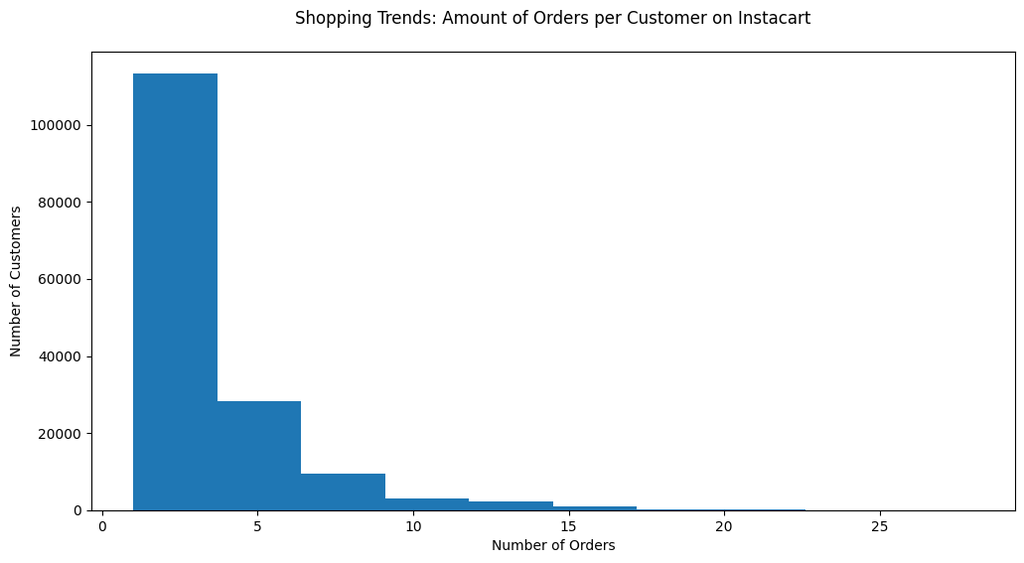

```python
user_sort_orders.plot(kind= 'hist', bins= 10, figsize= (12,6) )
plt.xlabel('Number of Orders')
plt.ylabel('Number of Customers')
plt.title("Shopping Trends: Amount of Orders per Customer on Instacart", pad= 20)
plt.show()
```

Most customers in the dataset have placed between 1 and 10 orders, with number of orders per customer sharply decreasing after just 1 order.

**Reviewer's comment v1**

Everything is correct here.

### [B3] What are the top 20 popular products (display their id and name)?

To identify the top 20 most popular products:

1. **Merge the datasets**: Combine `order_products` and `products` on `product_id` to access both the product IDs and names in a single DataFrame.
2. **Group the data**: Group by both `product_id` and `product_name` to aggregate the order counts for each product using `.size()`.
3. **Sort the results**: Use `.sort_values(ascending=False)` to rank products by their popularity.
4. **Display the top 20**: Use `.head(20)` to focus on the most frequently ordered products.
5. **Visualize the results**: Create a bar chart to highlight the top products and their order counts.

This will give you a clear view of the most popular products and their ranking.

```python
pro_pro_order = pd.merge(order_products, products, on= 'product_id')
product_popularity = pro_pro_order.groupby(['product_id', 'product_name']).size()
product_popularity_sorted = product_popularity.sort_values(ascending=False)
top_20_products = product_popularity_sorted.head(20)
top_20_fixed = top_20_products.reset_index()
#so grouping the product id and product name causes the illustration to have the product ids in the graph. Its ugly, but yall ask for both(id and name) so im making 2 graphs lol
#this is the easiest fix i could find in my studies
top_20_fixed.columns= ['product_id', 'product_name', 'sold']
print(top_20_fixed)
```

```
    product_id              product_name   sold
0        24852                    banana  66050
1        13176    bag of organic bananas  53297
2        21137      organic strawberries  37039
3        21903      organic baby spinach  33971
4        47209      organic hass avocado  29773
5        47766           organic avocado  24689
6        47626               large lemon  21495
7        16797              strawberries  20018
8        26209                     limes  19690
9        27845        organic whole milk  19600
10       27966       organic raspberries  19197
11       22935      organic yellow onion  15898
12       24964            organic garlic  15292
13       45007          organic zucchini  14584
14       39275       organic blueberries  13879
15       49683            cucumber kirby  13675
16       28204        organic fuji apple  12544
17        5876             organic lemon  12232
18        8277  apple honeycrisp organic  11993
19       40706    organic grape tomatoes  11781
```

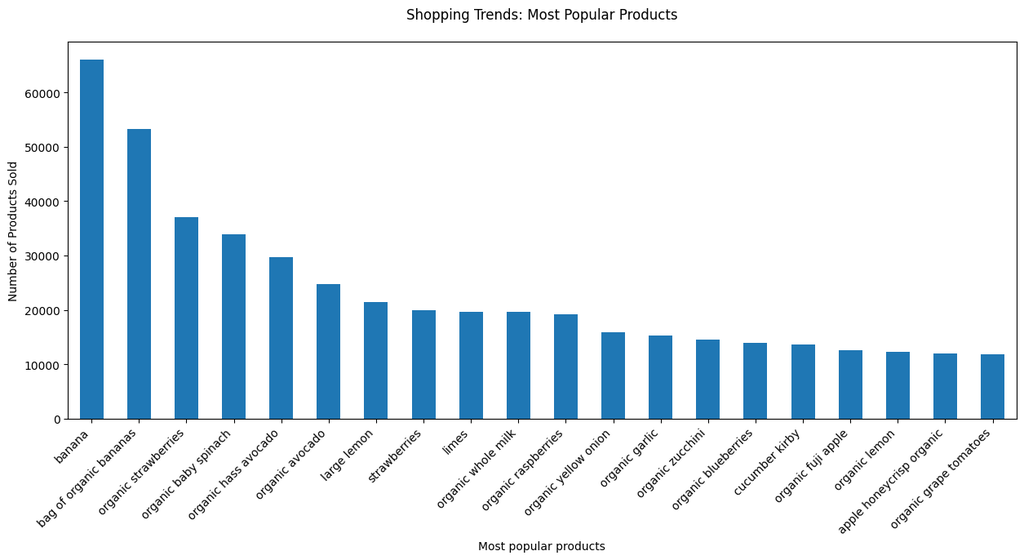

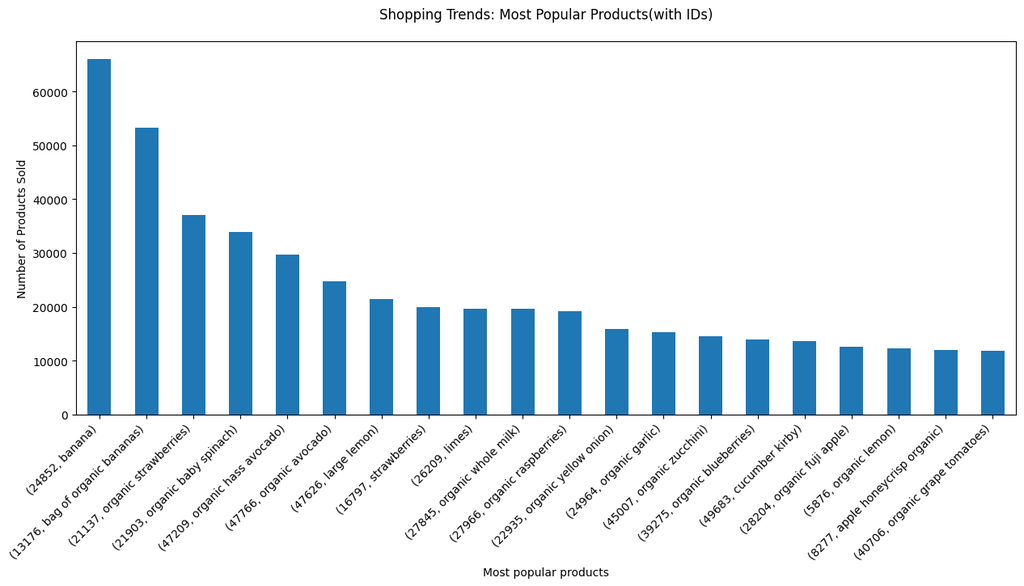

```python
top_20_fixed.plot(kind= 'bar', xlabel = 'Most popular products', y= 'sold',  ylabel = 'Number of Products Sold', x= 'product_name', figsize= [15,6], legend= False)
plt.title('Shopping Trends: Most Popular Products', pad= 20)
plt.xticks(rotation= 45, ha= 'right' )
plt.show()

top_20_products.plot(kind= 'bar', xlabel = 'Most popular products', y= 'sold',  ylabel = 'Number of Products Sold', x= 'product_name', figsize= [15,6], legend= False)
plt.title('Shopping Trends: Most Popular Products(with IDs)', pad= 20)
plt.xticks(rotation= 45, ha= 'right' )
plt.show()
```

The top 20 items are all produce, except for the milk. Looks like people want delicious and nutritious!

**Reviewer's comment v1**

Well done! Correct results and graph.

# [C] Hard (must complete at least two to pass)

### [C1] How many items do people typically buy in one order? What does the distribution look like?

To analyze how many items people typically buy in one order:

1. **Group the data** by `order_id` and count the number of products (`product_id`) in each order using `.count()`. This gives the number of items in each order.
2. **Aggregate the counts**: Use `.value_counts()` to determine how frequently different order sizes occur, and then sort the results with `.sort_index()` to organize by the number of items.
3. **Visualize the distribution**: Use a bar plot to show the frequency of orders for each size, with the x-axis representing the number of items and the y-axis representing the number of orders.

This will help you understand the typical size of a grocery order and identify any trends in purchasing behavior.

```python
product_count = order_products.groupby('order_id')['product_id'].count()
product_counts = product_count.value_counts()
product_count_sorted = product_counts.sort_index()
print(product_count_sorted)
```

```
1      21847
2      26292
3      29046
4      31054
5      31923
       ...
98         1
104        1
108        1
115        1
127        1
Name: product_id, Length: 90, dtype: int64
```

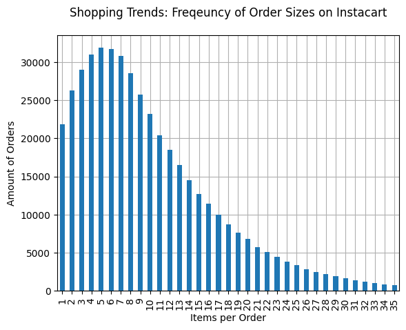

```python
product_count_sorted.head(35).plot(kind= 'bar', grid= True, zorder= 3, xlabel= 'Items per Order', ylabel= 'Amount of Orders')
plt.title("Shopping Trends: Freqeuncy of Order Sizes on Instacart", pad= 20)
plt.show()
```

```python
#It looks like most people grab anywhere from 4-6 items on average when they shop! Looks like the trend is towards small purchases!
#so crazy that people dont order larger order through the platform, I wonder why that is??
```

**Reviewer's comment v1**

Well done! In response to your question, it could be due to some free shipping promotion, not being a very large supermarket and more like a convenience store, etc.

The typical order contains 5 or 6 items, with most orders having between 1 and 20 items.

### [C2] What are the top 20 items that are reordered most frequently (display their names and product IDs)?

To find the top 20 most frequently reordered items:

1. **Filter the data**: Use `order_products['reordered'] == 1` to isolate only the products that have been reordered.
2. **Merge the datasets**: Combine the filtered `order_products` with the `products` dataset on `product_id` to get both the product names and IDs.
3. **Group the data**: Group by both `product_id` and `product_name` to calculate how many times each product was reordered, using `.size()`.
4. **Sort the results**: Use `.sort_values(ascending=False)` to rank the products by reorder frequency.
5. **Display the top 20**: Use `.head(20)` to focus on the most frequently reordered products.
6. **Visualize the data**: Create a bar chart to showcase the top reordered items and their frequencies.

This process highlights the products that customers consistently return to and reorder.

```python
reordered_products = order_products[order_products['reordered'] ==1]

merged_df = pd.merge(reordered_products, products, on= 'product_id')
reorder_count = merged_df.groupby(['product_id', 'product_name']).size()
reorder_count_sorted = reorder_count.sort_values(ascending = False)
reorder_count_sorted_fixed = reorder_count_sorted.reset_index()
reorder_count_sorted_fixed.columns= ['product_id', 'product_name', 'count']
print(reorder_count_sorted_fixed.head(20))
```

```
    product_id              product_name  count
0        24852                    banana  55763
1        13176    bag of organic bananas  44450
2        21137      organic strawberries  28639
3        21903      organic baby spinach  26233
4        47209      organic hass avocado  23629
5        47766           organic avocado  18743
6        27845        organic whole milk  16251
7        47626               large lemon  15044
8        27966       organic raspberries  14748
9        16797              strawberries  13945
10       26209                     limes  13327
11       22935      organic yellow onion  11145
12       24964            organic garlic  10411
13       45007          organic zucchini  10076
14       49683            cucumber kirby   9538
15       28204        organic fuji apple   8989
16        8277  apple honeycrisp organic   8836
17       39275       organic blueberries   8799
18        5876             organic lemon   8412
19       49235       organic half & half   8389
```

```python
reorder_count_sorted.head(20).plot(kind= 'bar',legend= False, x= 'product_name', y= 'count', xlabel= "Name of products", ylabel= "Number of products sold", figsize= [15,6])
plt.title('Shopping Trends: Most Frequently Reordered Products(with IDs)', pad= 20)
plt.xticks(rotation= 45)
plt.show()



reorder_count_sorted_fixed.head(20).plot(kind= 'bar',legend= False, x= 'product_name', y= 'count', xlabel= "Name of products", ylabel= "Number of products sold", figsize= [15,6])
plt.title('Shopping Trends: Most Frequently Reordered Products', pad= 20)
plt.xticks(rotation= 45)
plt.show()
```

[output not shown]

It looks like produce and dairy comprise the most reordered products as well. It makes sense that perishables would be the most reordered items.

**Reviewer's comment v1**

Correct results and conclusions 💫

### [C3] For each product, what proportion of its orders are reorders?

To calculate the proportion of orders for each product that are reorders:

1. **Merge the datasets**: Combine `order_products` with the `products` dataset to access product names and IDs in the same DataFrame.
2. **Group the data**: Group by `product_id` and `product_name` to isolate each product's order history.
3. **Calculate the mean of `reordered`**: Use `.mean()` on the `reordered` column to compute the proportion of orders for each product that were reorders. The value represents the reorder rate.
4. **Sort the results**: Use `.sort_values(ascending=False)` to rank products by their reorder rates.
5. **Convert to a DataFrame**: Use `.reset_index()` to organize the grouped data into a readable DataFrame.
6. **Optional Sorting**: Sort the results by `product_id` or another column for better clarity.

This approach provides insights into how frequently each product is reordered, helping identify customer favorites or staples.

### [C4] For each customer, what proportion of their products ordered are reorders?

To calculate the proportion of products reordered by each customer:

1. **Merge the datasets**: Combine `order_products` with `orders` to link order and customer information.
2. **Group the data**: Group by `user_id` to focus on each customer's ordering behavior.
3. **Calculate the mean of `reordered`**: Use `.mean()` on the `reordered` column to determine the proportion of products reordered by each customer.
4. **Sort the results**: Use `.sort_values(ascending=False)` to identify customers with the highest reorder rates.
5. **Convert to a DataFrame**: Use `.reset_index()` to format the grouped data into a structured DataFrame for further analysis.

This analysis reveals the extent to which individual customers reorder products, providing insights into customer loyalty and preferences.

### [C5] What are the top 20 items that people put in their carts first?

To identify the top 20 items that people most frequently add to their carts first:

1. **Merge the datasets**: Combine `order_products` with `products` to link product names and IDs.
2. **Filter the data**: Focus on rows where `add_to_cart_order` equals 1, indicating the first item added to the cart.
3. **Group the data**: Group by `product_id` and `product_name` to aggregate the count of how often each product was the first in a cart.
4. **Count occurrences**: Use `.count()` to calculate the total number of times each product was the first added.
5. **Sort the results**: Use `.sort_values(ascending=False)` to rank products by their first-in-cart frequency.
6. **Display the top 20**: Use `.head(20)` to extract the most popular first-in-cart items.

This provides insights into which products customers prioritize in their shopping process.